# Cell-cell communication with CellChat

### Circle plot: Visualizing Interaction Counts or Strength

These aggregated interactions can be visualized using a circle plot, where each node represents a cell group and the edges indicate communication between them. The width of the edges reflects the strength of the interaction ("counts" or "weight"), while the size of each node can be scaled according to the number of cells in the corresponding group.

[figure not shown]

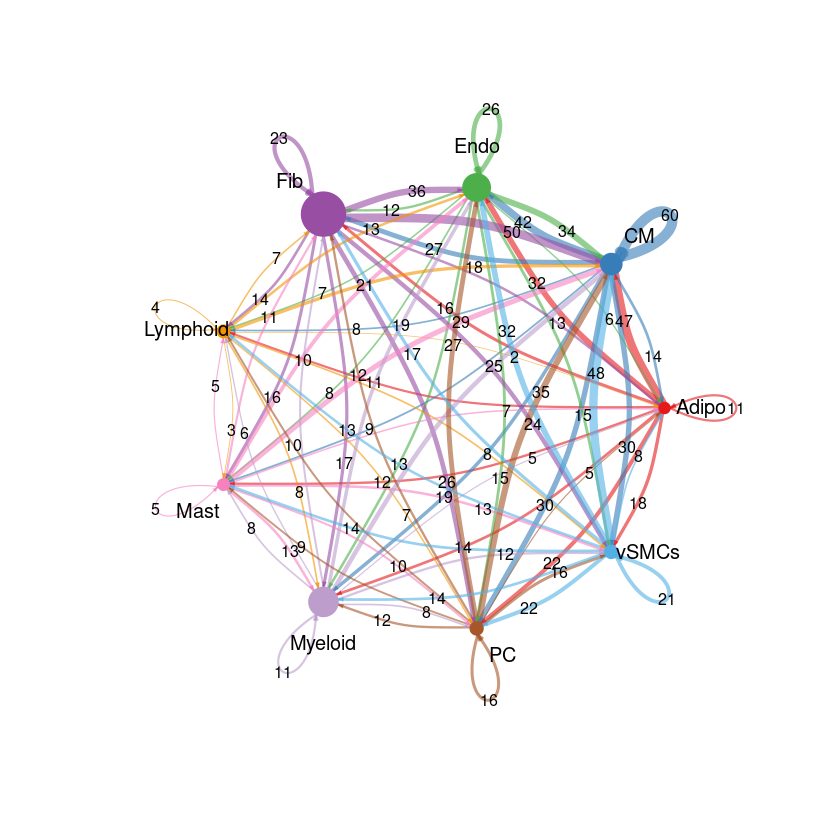

[figure not shown]

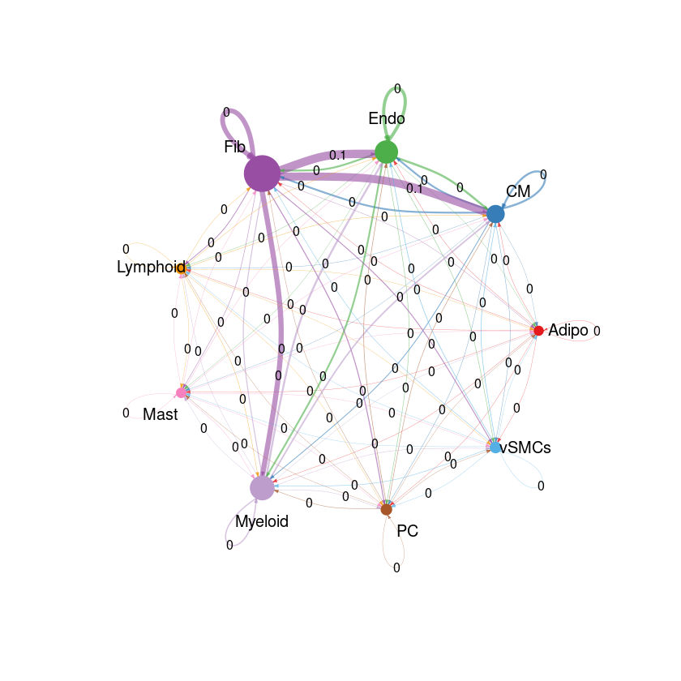

```r
# Calculate the size (number of cells) of each cell group
groupSize <- as.numeric(table(cellchat@idents))

# Generate a circle plot to visualize the number of interactions between cell groups
netVisual_circle(cellchat@net$count,                # A weighted matrix representing the connections
                vertex.weight = groupSize,          # Set node sizes
                weight.scale = T,                   # Scale edge weights for visualization clarity
                label.edge = T,                     # Whether or not shows the label of edges
                title.name = "Number of interactions")          # Title of the plot

# Generate a circle plot to visualize the weights between cell groups
netVisual_circle(cellchat@net$weight,                # A weighted matrix representing the connections
                vertex.weight = groupSize,          # Set node sizes
                weight.scale = T,                   # Scale edge weights for visualization clarity
                label.edge = T,                     # Whether or not shows the label of edges
                title.name = "Interaction weights/strength")        # Title of the plot
```

### Heatmap: Visualizing Interaction Counts or Strength

The heatmap provides a detailed view of cell–cell communication by displaying either the number of interactions or the interaction strength (communication probability) between each pair of cell groups. To aid interpretation, two summary bar plots are included:

- The top bar plot shows the total incoming interactions for each target group by summing the values in each column.
- The right-side bar plot displays the total outgoing interactions from each source group by summing the values in each row.

The heatmap can be particularly useful for identifying dominant communication hubs and asymmetric interactions. Depending on the analysis focus, users can choose to display: 'counts' or 'weights'

```
Do heatmap based on a single object
```

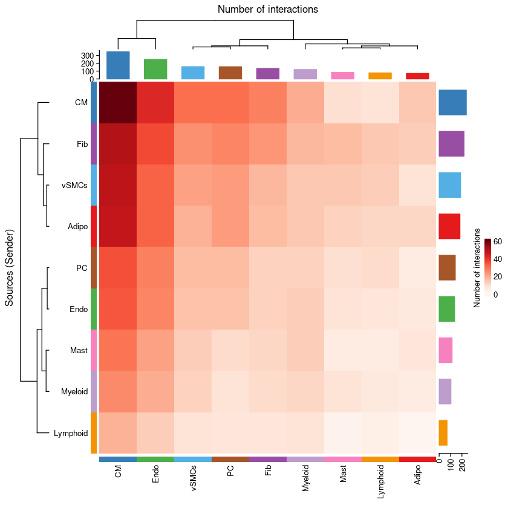

```r
netVisual_heatmap(
  object = cellchat,                          # CellChat object
  measure = c("count"),                       # "count" (number of interactions) or "weight" (total interaction stregth)
  signaling = NULL,                           # a character vector giving the name of signaling networks
  slot.name = c( "net"),                      # the slot name of object:
                                                 # slot.name = "net" when visualizing links at the level of ligands/receptors;
                                                 # slot.name = "netP" when visualizing links at the level of signaling pathways
  title.name = "Number of interactions",      # the name of the title
  cluster.rows = TRUE,                       # whether cluster rows
  cluster.cols = TRUE,                       # whether cluster columns
)
```

### Bubble plot: Significant Ligand-Receptor interactions

To visualize significant ligand–receptor (L–R) interactions between cell groups, CellChat provides the netVisual_bubble function. This plot effectively summarizes how different cell types communicate through specific signaling molecules. Each bubble in the plot represents a ligand–receptor pair involved in communication from a source (sending) group to a target (receiving) group.

- The x-axis denotes the interacting cell group pair
- The y-axis lists the L–R pairs.
- Bubble color indicates the interaction strength (i.e., the communication probability).
- Bubble size reflects the statistical significance You can customize the plot to filter for specific signaling pathways, senders, or receivers.

```
Comparing communications on a single object
```

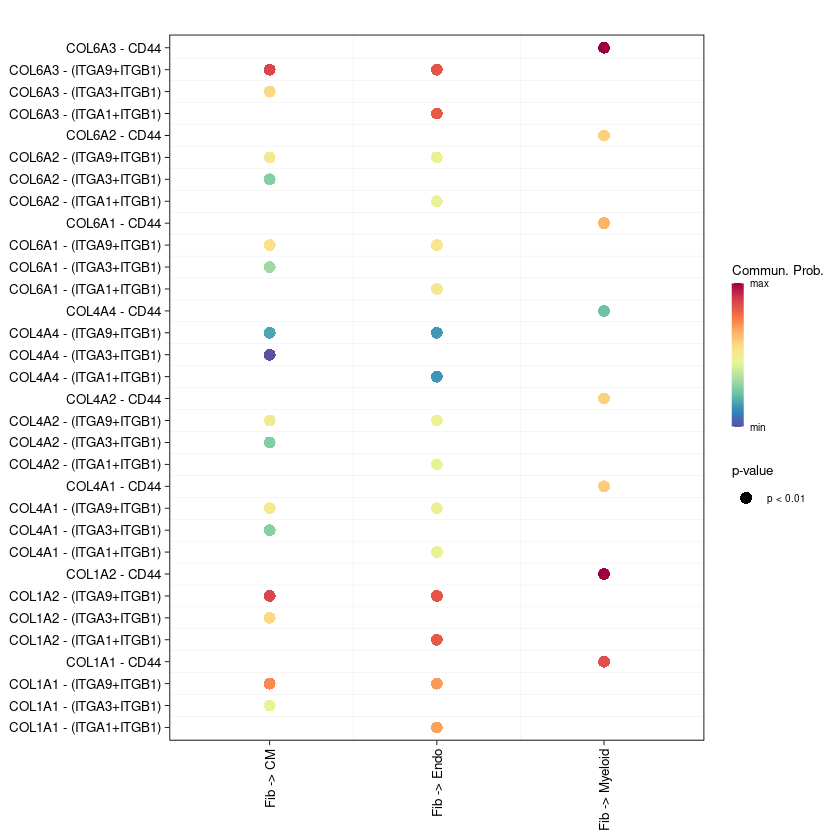

```r
netVisual_bubble(cellchat,                                  # CellChat object
                sources.use = "Fib",                        # a vector giving the index or the name of source cell groups
                targets.use = c("CM", "Endo", "Myeloid"),   # a vector giving the index or the name of target cell groups.
                thresh = 0.05,                              # threshold of the p-value for determining significant interaction
                signaling = "COLLAGEN",                     # a character vector giving the name of signaling pathways of interest
                title.name = ""	                            # title name of the plot
                )
```

### Chord diagram

Similar to Bubble plot, CellChat provides a function netVisual_chord_gene for drawing Chord diagram to show all the interactions (L-R pairs or signaling pathways) from some cell groups to other cell groups.

- each sector on the outer ring represents either a ligand, receptor, or signaling pathway, depending on the chosen level of analysis.
- the color of each edge is based on the source (sender) group
- the thickness of the edge reflects the interaction strength (i.e. thicker edge line indicates a stronger signal)
- each inner bar is colored according to the target group that receives the signal.

[figure not shown]

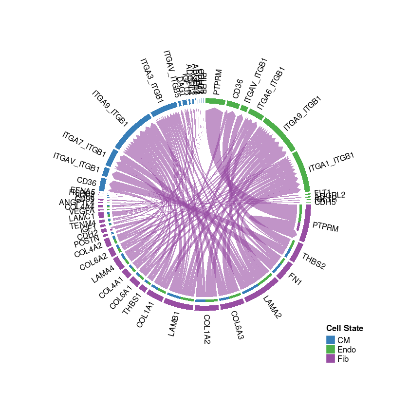

```r
netVisual_chord_gene(cellchat,                                  # CellChat object
                    signaling = NULL,                           # a character vector giving the name of signaling networks
                    slot.name = "net",                          # the slot name of object:
                                                                # slot.name = "net" when visualizing links at the level of ligands/receptors;
                                                                # slot.name = "netP" when visualizing links at the level of signaling pathways
                    sources.use = "Fib",                        # a vector giving the index or the name of source cell groups
                    targets.use = c("CM", "Endo"),              # a vector giving the index or the name of target cell groups.
                    thresh = 0.05,                              # threshold of the p-value for determining significant interaction
                    title.name = ""	                            # title name of the plot
                    )
```

# Unexplored feature

- **Multiple visualization and Network Interpretation** Beyond basic interaction plots, CellChat offers advanced tools for exploring high-order features of inferred communication networks. It integrates methods from social network analysis, pattern recognition, and manifold learning to provide a deeper understanding of the structure and organization of cell–cell communication.
- **Comparative analysis** CellChat supports comparative analysis to assess how cell–cell communication networks change across different biological conditions (e.g., disease vs. healthy, treated vs. untreated). Using quantitative contrasts and joint manifold learning, it can identify significant differences in signaling activity, communication strength, and network topology.
- **Spatially resolved omics data**: CellChat allow the inference of spatially proximal cell-cell communication between interacting cell groups from spatially resolved transcriptomics

# Citation

- **CellChat v1**: *Inference and analysis of cell-cell communication using CellChat. Suoqin Jin et al., Nat. Comm. 2021* li
- **CellChat v2**: *CellChat for systematic analysis of cell–cell communication from single-cell transcriptomics. Suoqin Jin et al. Nat Protoc. 2024*